# Tutorial de Cálculo para Probabilidad y Estadística

Mauricio Bucca

## 1. Funciones

### 1.1 Definición Formal

Una función $f(x)$ es una regla que asigna a cada elemento $x$ de un conjunto $X$ exactamente un elemento $y$ de un conjunto $Y$. Formalmente, una función se puede definir como:

$$f: X \rightarrow Y$$

donde $X$ es el dominio de la función y $Y$ es el codominio. Esto significa que la función toma valores de $X$ (el dominio) y los transforma en valores en $Y$ (el codominio). Cada valor individual en $X$ se llama argumento de la función, y cada valor correspondiente en $Y$ es el valor de la función para ese argumento.

### 1.2 Definición Intuitiva

Podemos pensar en una función como una máquina que toma un valor $x$ como entrada y produce un valor $y$ como salida. Esta “máquina” sigue la regla específica dada por la función. Por ejemplo, la función $f(x) = x^2$ toma un número $x$ y produce su cuadrado como salida. Cada valor $x$ tiene un único valor $y$ asociado. Gráficamente, una función representa una curva en un plano cartesiano donde el eje $x$ representa las entradas y el eje $y$ representa las salidas.

### 1.3 Ejemplo y Gráfico

Consideremos la función $f(x) = 2x + 1$, donde $x$ pertenece a los números reales.

Para calcular los valores de esta función, simplemente tomamos cualquier valor de $x$, lo multiplicamos por 2, y luego sumamos 1. Por ejemplo, si $x = 2$, entonces $f(x) = 2 \times 2 + 1 = 5$.

Podemos visualizar esta función en un gráfico con gráficos más atractivos y una paleta de colores más agradable:

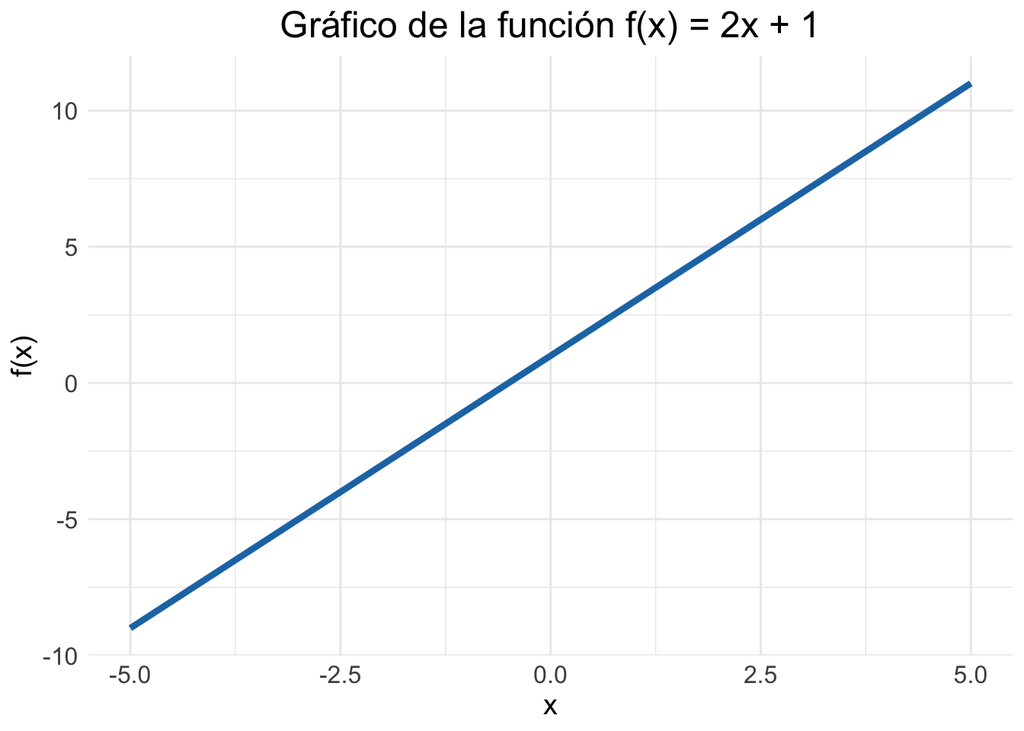

Gráfico de la función f(x) = 2x + 1

```r
# Load required libraries
library(ggplot2)

# Create a function to calculate f(x) = 2x + 1
f_x <- function(x) {
  2 * x + 1
}

# Create a data frame with x values from -5 to 5
x_values <- seq(-5, 5, 0.1)
data_df <- data.frame(x = x_values)

# Calculate the y values for f(x) = 2x + 1
data_df$y <- f_x(data_df$x)

# Create the plot for the function f(x) = 2x + 1
ggplot(data_df, aes(x, y)) +
  geom_line(color = "#1F77B4", size = 1.5) +
  labs(title = "Gráfico de la función f(x) = 2x + 1",
       x = "x",
       y = "f(x)") +
  theme_minimal() +
  theme(plot.title = element_text(size = 18, hjust = 0.5),
        axis.title = element_text(size = 14),
        axis.text = element_text(size = 12))
```

Este gráfico ilustra visualmente cómo cambia el valor de $f(x)$ a medida que $x$ varía de -5 a 5.

## 2. Funciones Exponenciales

### 2.1 Definición Formal

Una función exponencial es una función de la forma $f(x) = a^x$, donde ‘a’ es una constante positiva diferente de 1. Las funciones exponenciales tienen algunas propiedades importantes que las distinguen de otras funciones.

### 2.2 Propiedades de las funciones exponenciales

Las funciones exponenciales obedecen las siguientes reglas, que son útiles para manipular y simplificar las expresiones exponenciales:

1. **Producto de potencias**: $a^m \cdot a^n = a^{m+n}$

   Ejemplo: $3^2 \cdot 3^4 = 3^{2+4} = 3^6 = 729$
2. **Cociente de potencias**: $a^m / a^n = a^{m-n}$

   Ejemplo: $5^4 / 5^2 = 5^{4-2} = 5^2 = 25$
3. **Potencia de una potencia**: $(a^m)^n = a^{mn}$

   Ejemplo: $(3^3)^2 = 3^{3*2} = 3^6 = 729$
4. **Exponente cero**: $a^0 = 1$

   Ejemplo: $10^0 = 1$
5. **Exponente negativo**: $a^{-n} = 1/a^n$

   Ejemplo: $4^{-2} = 1/4^2 = 1/16 = 0.0625$
6. **Exponentes de productos**: $(ab)^n = a^n \cdot b^n$

   Ejemplo: $(2*4)^3 = 2^3 \cdot 4^3 = 8 \cdot 64 = 512$
7. **Exponentes de cocientes**: $(a/b)^n = a^n / b^n$

   Ejemplo: $(6/3)^2 = 6^2 / 3^2 = 36 / 9 = 4$

### 2.3 Ejemplo y Gráfico

Consideremos la función exponencial $f(x) = 2^x$.

Para calcular los valores de esta función, simplemente tomamos cualquier valor de $x$ y lo usamos como el exponente de 2. Por ejemplo, si $x = 2$, entonces $f(x) = 2^2 = 4$.

Podemos visualizar esta función en un gráfico con gráficos más atractivos y una paleta de colores más agradable:

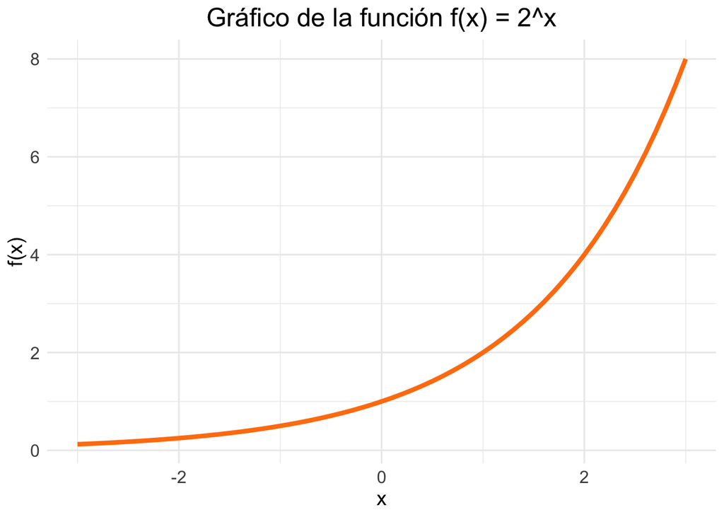

```r
# Create a data frame with x values from -3 to 3
x_values <- seq(-3, 3, 0.1)
data_df <- data.frame(x = x_values)

# Calculate the y values for f(x) = 2^x
data_df$y <- 2 ^ x_values

# Create the plot for the function f(x) = 2^x
ggplot(data_df, aes(x, y)) +
  geom_line(color = "#FF7F0E", size = 1.5) +
  labs(title = "Gráfico de la función f(x) = 2^x",
       x = "x",
       y = "f(x)") +
  theme_minimal() +
  theme(plot.title = element_text(size = 18, hjust = 0.5),
        axis.title = element_text(size = 14),
        axis.text = element_text(size = 12))
```

Este gráfico muestra cómo cambia el valor de $f(x)$ a medida que $x$ varía de -3 a 3. Puedes observar cómo los valores de $f(x)$ crecen rápidamente para valores positivos de $x$ y se acercan a 0 para valores negativos de $x$, lo cual es una característica distintiva de las funciones exponenciales.

## 3. Sumatorias

### 3.1 Definición Formal

La sumatoria es una notación matemática que representa la suma de una secuencia de valores. Formalmente, una sumatoria se puede definir como:

$$\sum_{i=1}^{n} a_i$$

donde $a_i$ son los términos de la secuencia y $n$ es el número total de términos en la secuencia. En esta notación, $i$ es el índice que nos dice qué término de la secuencia estamos sumando, y $n$ es el límite superior, que nos indica hasta qué término debemos sumar.

### 3.2 Definición Intuitiva

Podemos pensar en la sumatoria como la adición de todos los valores de una secuencia. La notación $\sum$ nos indica que debemos sumar todos los términos de la secuencia desde $i = 1$ hasta $i = n$. Por ejemplo, si tenemos la secuencia $a = [a_1, a_2, a_3, a_4, a_5]$, entonces la sumatoria de los términos de $a$ sería $a_1 + a_2 + a_3 + a_4 + a_5$.

### 3.3 Propiedades y Ejemplo

Las sumatorias tienen varias propiedades que pueden ser útiles para simplificar cálculos. Aquí vamos a examinar dos de ellas.

#### Propiedad 1: Suma de Constantes

La sumatoria de una constante multiplicada por el número de términos $n$ es igual a la constante multiplicada por la suma de los términos.

$$\sum_{i=1}^{n} c = c \cdot n$$

Ejemplo: Consideremos la secuencia de cinco términos: $1, 1, 1, 1, 1$.

1. Encontrar la sumatoria de la secuencia:
   $$\sum_{i=1}^{5} 1 = 1 + 1 + 1 + 1 + 1 = 5$$

Por lo tanto, podemos ver que la sumatoria de esta constante (1) multiplicada por el número de términos (5) es igual a la constante (1) multiplicada por la suma de los términos (5).

#### Propiedad 2: Suma de Términos Consecutivos

La sumatoria de los $n$ primeros números naturales consecutivos es igual a $\frac{n(n + 1)}{2}$.

$$\sum_{i=1}^{n} i = \frac{n(n + 1)}{2}$$

Ejemplo: Consideremos la sumatoria de los primeros cinco números naturales: $1, 2, 3, 4, 5$.

1. Encontrar la sumatoria de los cinco primeros números naturales:
   $$\sum_{i=1}^{5} i = 1 + 2 + 3 + 4 + 5 = 15$$
   $$\frac{5(5 + 1)}{2} = 15$$

Por lo tanto, podemos ver que la sumatoria de los primeros cinco números naturales es igual a $\frac{5(5 + 1)}{2}$, que también es 15.

### 3.4 Aplicación

Consideremos un escenario en el cual tenemos un conjunto de datos que representa las ventas diarias de una empresa durante una semana:

| Día | Ventas |
| --- | --- |
| Lunes | 1500 |
| Martes | 1200 |
| Miércoles | 1800 |
| Jueves | 1300 |
| Viernes | 1400 |
| Sábado | 2000 |
| Domingo | 1700 |

Queremos determinar el total de ventas durante la semana utilizando la sumatoria de los datos proporcionados.

```r
# Definir las ventas diarias
ventas_diarias <- c(1500, 1200, 1800, 1300, 1400, 2000, 1700)

# Calcular el total de ventas durante la semana
total_ventas_semana <- sum(ventas_diarias)

print(total_ventas_semana)
```

```
## [1] 10900
```

El código de arriba calculará la sumatoria de las ventas diarias durante la semana, lo que nos dará el total de ventas realizadas en ese período de tiempo.

## 4. Derivadas

### 4.1 Definición Formal

La derivada de una función $f(x)$ en un punto $x$ se define como el límite del cociente incremental cuando el cambio en $x$ tiende a cero. Formalmente, la derivada se puede definir como:

$$f'(x) = \lim_{h \to 0} \frac{f(x +
h) - f(x)}{h}$$

donde $h$ es una cantidad muy pequeña que representa el cambio en $x$.

### 4.2 Definición Intuitiva

Podemos pensar en la derivada como la tasa de cambio instantáneo de una función en un punto específico. La derivada nos indica cómo cambia el valor de $y$ con respecto a $x$ en un punto particular.

La derivada de una función en un punto puede interpretarse como la pendiente de la línea tangente a la gráfica de la función en ese punto. Vamos a mostrar esto con un gráfico utilizando la función $f(x) = x^2$, y calcularemos la derivada en el punto $x = 2$.

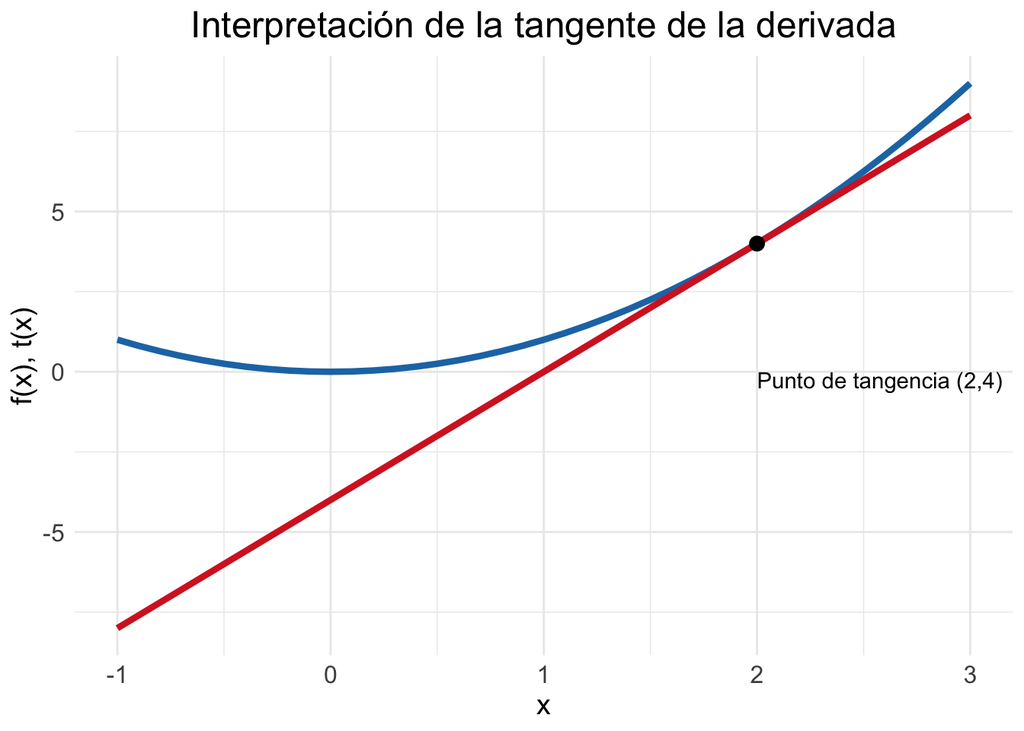

Interpretación de la derivada como tangente

```r
# Create a vector of x values from -1 to 3
x_values <- seq(-1, 3, 0.1)

# Define the function f(x) = x^2
f_x <- function(x) {x^2}

# Calculate the corresponding y values for the function f(x) = x^2
y_values <- f_x(x_values)

# Define the tangent line t(x) = 4*x - 4
t_x <- function(x) {4*x - 4}

# Calculate the corresponding y values for the tangent line
y_tangente <- t_x(x_values)

# Create a data frame for the tangent point (2, 4)
tangent_point <- data.frame(x = 2, y = 4)

# Create the plot for the function f(x) = x^2 and its tangent line at x = 2
grafico_tangente <- ggplot() +
  geom_line(data = data.frame(x = x_values, y = y_values), aes(x, y), color = "#1F77B4", size = 1.5) +
  geom_line(data = data.frame(x = x_values, y = y_tangente), aes(x, y), color = "#D62728", size = 1.5) +
  geom_point(data = tangent_point, aes(x, y), color = "black", size = 3) +
  annotate("text", x = 2, y = 0, label = "Punto de tangencia (2,4)", hjust = 0, vjust = 1) +
  labs(title = "Interpretación de la tangente de la derivada",
       x = "x",
       y = "f(x), t(x)") +
  theme_minimal() +
  theme(plot.title = element_text(size = 18, hjust = 0.5),
        axis.title = element_text(size = 14),
        axis.text = element_text(size = 12))

print(grafico_tangente)
```

En este gráfico, la línea azul representa la función $f(x) = x^2$, la línea roja representa la línea tangente en el punto $x = 2$, y el punto negro indica el punto de tangencia. Como puedes observar, la pendiente de la línea tangente en $x = 2$ es igual al valor de la derivada de la función en ese punto.

### 4.3 Propiedades y Ejemplo

#### Propiedad 1: Regla de la Potencia

La derivada de una función $f(x) = x^n$ donde $n$ es una constante, es igual a $n \cdot x^{n-1}$.

$$\frac{d}{dx} (x^n) = n \cdot x^{n-1}$$

Ejemplo: Consideremos la función $f(x) = x^2$.

1. Encontrar la derivada de $f(x)$:
   $$\frac{d}{dx} (x^2) = 2x^{2-1} = 2x$$

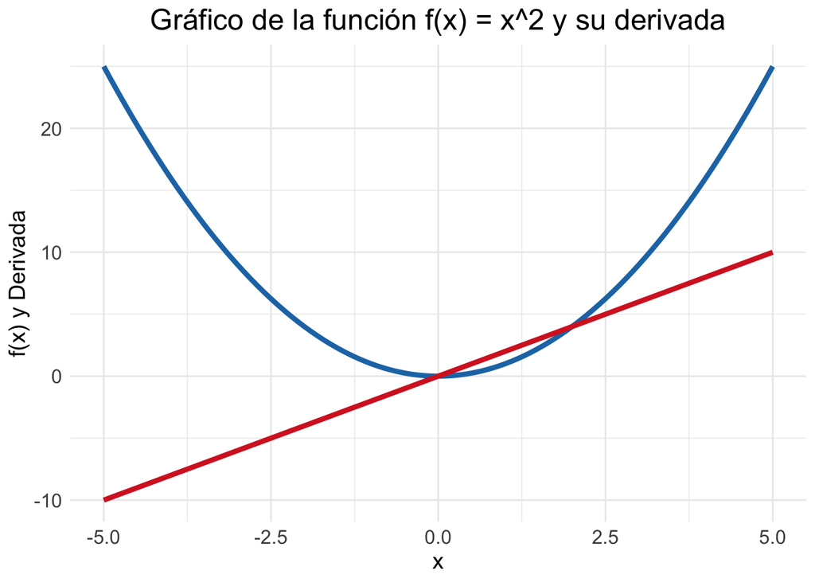

Gráfico de la función f(x) = x^2 y su derivada

```r
# Create a vector of x values from -5 to 5
x_values <- seq(-5, 5, 0.1)

# Define the function f(x) = x^2
f_x <- function(x) {x^2}

# Calculate the corresponding y values for the function f(x) = x^2
y_values <- f_x(x_values)

# Calculate the corresponding values for the derivative of f(x) = x^2
derivada_values <- 2 * x_values

# Create the plot for the function f(x) = x^2 and its derivative
grafico_derivada <- ggplot() +
  geom_line(data = data.frame(x = x_values, y = y_values), aes(x, y), color = "#1F77B4", size = 1.5) +
  geom_line(data = data.frame(x = x_values, y = derivada_values), aes(x, y), color = "#D62728", size = 1.5) +
  labs(title = "Gráfico de la función f(x) = x^2 y su derivada",
       x = "x",
       y = "f(x) y Derivada") +
  scale_color_manual(values = c("#1F77B4", "#D62728")) +
  theme_minimal() +
  theme(plot.title = element_text(size = 18, hjust = 0.5),
        axis.title = element_text(size = 14),
        axis.text = element_text(size = 12))

print(grafico_derivada)
```

#### Propiedad 2: Regla de la Suma

La derivada de la suma de dos funciones es igual a la suma de las derivadas de esas funciones. Es decir, si $f(x) = g(x) + h(x)$, entonces $f'(x) = g'(x) + h'(x)$.

$$\frac{d}{dx} (g(x) + h(x)) = g'(x)
+ h'(x)$$

Ejemplo: Consideremos las funciones $g(x) = 2x^2$ y $h(x) = 3x^3$. Queremos encontrar la derivada de su suma $f(x) = g(x) + h(x)$:

1. Encontrar la derivada de $f(x)$: Primero, calculamos las derivadas de $g(x)$ y $h(x)$:
   $$g'(x) = 4x$$
   $$h'(x) = 9x^2$$

Entonces,
$$f'(x) = g'(x) +
h'(x) = 4x + 9x^2$$

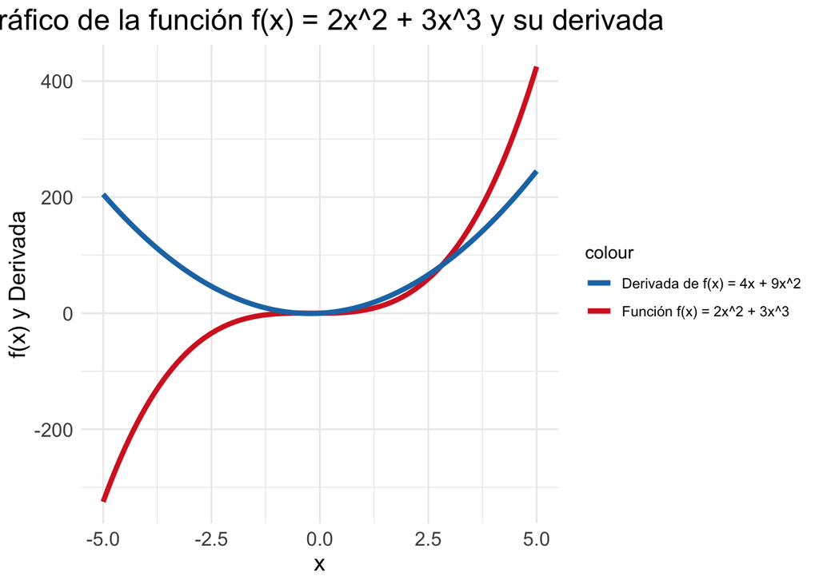

Gráfico de la función f(x) = 2x^2 + 3x^3 y su derivada

```r
# Calculate the corresponding y values for the function f(x) = 2x^2 + 3x^3
y_suma_values <- 2 * x_values^2 + 3 * x_values^3

# Calculate the corresponding values for the derivative of f(x) = 2x^2 + 3x^3
derivada_suma_values <- 4 * x_values + 9 * x_values^2

# Create the plot for the function f(x) = 2x^2 + 3x^3 and its derivative
grafico_derivada_suma <- ggplot(data.frame(x = x_values, y = y_suma_values, derivada = derivada_suma_values), aes(x)) +
  geom_line(aes(y = y_suma_values, color = "Función f(x) = 2x^2 + 3x^3"), size = 1.5) +
  geom_line(aes(y = derivada_suma_values, color = "Derivada de f(x) = 4x + 9x^2"), size = 1.5) +
  labs(title = "Gráfico de la función f(x) = 2x^2 + 3x^3 y su derivada",
       x = "x",
       y = "f(x) y Derivada") +
  scale_color_manual(values = c("#1F77B4", "#D62728")) +
  theme_minimal() +
  theme(plot.title = element_text(size = 18, hjust = 0.5),
        axis.title = element_text(size = 14),
        axis.text = element_text(size = 12))

print(grafico_derivada_suma)
```

### 4.4 Aplicación

Considera la población de un país en función del tiempo, $P(t)$, donde $t$ representa el tiempo en años. La tasa de cambio de la población, que se puede considerar como el crecimiento de la población, es simplemente la derivada de $P(t)$ con respecto al tiempo, $P'(t)$.

Supongamos que la población de un país en un año $t$ está dada por la función $P(t) = 500 + 20t^2$. Queremos encontrar la tasa de cambio de la población en el año $t = 10$.

Primero, calculamos la derivada de $P(t)$:
$$P'(t) = \frac{d}{dt} (500 + 20t^2) = 40t$$

Luego, evaluamos la derivada en $t = 10$:
$$P'(10) = 40 \cdot 10 =
400$$

Por lo tanto, la tasa de cambio de la población en el año $t = 10$ es de 400 personas por año.

## 5. Integrales Discretas (Sumatorias)

### 5.1 Definición Formal

La integral discreta de una función $f(x)$ en un conjunto discreto de puntos $\{x_1, x_2, ..., x_n\}$ se puede representar mediante una sumatoria. Formalmente, la integral discreta se puede definir como:

$$\sum_{i=1}^{n} f(x_i) \cdot \Delta x$$

donde $\Delta x$ es la distancia entre los puntos $x_i$ y $x_{i+1}$.

### 5.2 Definición Intuitiva

Podemos pensar en la integral discreta como la suma de áreas de rectángulos con base $\Delta x$ y altura $f(x_i)$, donde $x_i$ son los puntos del conjunto.

### 5.3 Propiedades

La integral discreta tiene las siguientes propiedades:

1. **Linearidad**: La integral discreta de la suma de dos funciones es igual a la suma de las integrales discretas de las dos funciones.

   $$\sum_{i=1}^{n} (f(x_i) + g(x_i)) \cdot
   \Delta x = \sum_{i=1}^{n} f(x_i) \cdot \Delta x + \sum_{i=1}^{n} g(x_i)
   \cdot \Delta x$$
2. **Escalabilidad**: La integral discreta de una constante veces una función es igual a la constante veces la integral discreta de la función.

   $$\sum_{i=1}^{n} (c \cdot f(x_i)) \cdot
   \Delta x = c \cdot \sum_{i=1}^{n} f(x_i) \cdot \Delta x$$

donde $c$ es una constante.

### 5.4 Ejemplo y Gráfico

#### Paso 1: Definir la secuencia de puntos

Comenzamos definiendo una secuencia de puntos desde 0 hasta 4. Estos son los valores de $x$ para los que deseamos calcular la integral discreta.

```r
# Crear la secuencia de puntos
puntos <- 0:4
```

#### Paso 2: Calcular los valores de $f(x)$

Para cada valor de $x$, calculamos el valor correspondiente de $f(x) = x^2$. Esto se logra al elevar cada valor en la secuencia al cuadrado.

```r
# Calcular los valores correspondientes de y para la función f(x) = x^2
y_values <- puntos^2
```

#### Paso 3: Calcular $\Delta x$

Calculamos $\Delta x$, que es la distancia entre cada par de puntos sucesivos en la secuencia. En este caso, como los puntos están igualmente espaciados, $\Delta x$ es constante e igual a 1.

```r
# Calcular el incremento entre puntos
delta_x <- diff(puntos)
```

#### Paso 4: Calcular la integral discreta

De acuerdo con la definición formal de la integral discreta, la integral es la suma de los productos $f(x_i) \cdot \Delta x$ para cada $x_i$ en la secuencia. En este caso, multiplicamos cada valor de $f(x)$ por el correspondiente $\Delta x$ y luego sumamos todos estos productos.

```r
# Calcular la integral discreta
integral_discreta <- sum(y_values[-1] * delta_x)
```

#### Paso 5: Crear el gráfico

Vamos a usar `geom_rect` para visualizar los rectángulos que representan los términos de la suma en la integral discreta.

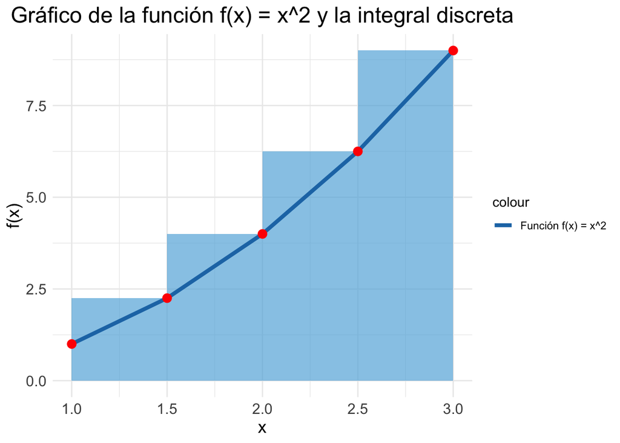

```r
# Load required library
library(ggplot2)

# Assuming puntos and y_values are defined appropriately
puntos <- c(1, 1.5, 2, 2.5, 3)
y_values <- puntos^2

# Create a dataframe with the integral discrete rectangles
integral_data <- data.frame(xmin = puntos[-length(puntos)],
                            xmax = puntos[-1],
                            ymin = 0,
                            ymax = y_values[-1])

# Create a dataframe with the function values
function_data <- data.frame(x = puntos, y = y_values)

# Create the plot for the function f(x) = x^2 and the integral discrete
grafico_integral_discreta <- ggplot() +
  geom_rect(data = integral_data, aes(xmin = xmin, xmax = xmax, ymin = ymin, ymax = ymax), fill = "#63B2DE", alpha = 0.7) +
  geom_line(data = function_data, aes(x = x, y = y, color = "Función f(x) = x^2"), size = 1.5) +
  geom_point(data = function_data, aes(x = x, y = y), color = "red", size = 3) +
  labs(title = "Gráfico de la función f(x) = x^2 y la integral discreta",
       x = "x",
       y = "f(x)") +
  labs(fill = "Área bajo la curva") +
  scale_color_manual(values = c("#1F77B4")) +
  theme_minimal() +
  theme(plot.title = element_text(size = 18, hjust = 0.5),
        axis.title = element_text(size = 14),
        axis.text = element_text(size = 12))

print(grafico_integral_discreta)
```

De esta manera, el gráfico y el código ilustran visualmente cómo se calcula una integral discreta: mediante la suma de áreas de rectángulos con base $\Delta x$ y altura $f(x_i)$, para cada punto $x_i$ en un conjunto dado. En el gráfico, cada rectángulo representa un término de la suma en la integral discreta.

### 5.5 Aplicación: Estimación de la Población Total

Suponga que se tiene una función $P(t)$ que representa la población de un país en el tiempo. Para estimar la población total durante un período de tiempo, se podría utilizar una integral discreta.

Por ejemplo, supongamos que tenemos la siguiente función de población $P(t) = 50t + 100$ y queremos estimar la población total del país entre los años 2000 (t = 0) y 2005 (t = 5).

Primero, creamos el conjunto de puntos para los años $\{0, 1, 2, 3, 4, 5\}$.

Luego, calculamos los valores de $P(t)$ para estos años:
$$P(t) = \{100, 150, 200, 250, 300,
350\}$$
.

Finalmente, utilizamos la fórmula de la integral discreta para estimar la población total:

```r
# Crear el conjunto de puntos para los años
años <- 0:5

# Calcular los valores de P(t)
valores_P <- 50 * años + 100

# Calcular el incremento entre puntos
delta_t <- diff(años)

# Calcular la integral discreta (población total estimada)
poblacion_total_estimada <- sum(valores_P * delta_t)
poblacion_total_estimada
```

```
## [1] 1350
```

La población total estimada durante este período de tiempo es 1350.

## 6. Integrales Continuas

### 6.1 Definición Formal

La integral de una función $f(x)$ en un intervalo $[a, b]$ representa el área bajo la curva de la función en el intervalo dado. Formalmente, la integral se puede definir como:

$$\int_{a}^{b} f(x) \, dx$$

### 6.2 Definición Intuitiva

Podemos pensar en la integral como la suma acumulada de infinitos rectángulos bajo la curva de la función en el intervalo $[a, b]$. La integral nos da una medida del “área” encerrada entre la curva de la función y el eje $x$ en el intervalo dado.

### 6.3 Propiedades

#### Propiedad 1: Linealidad

La integral de una constante multiplicada por una función es igual a la constante multiplicada por la integral de la función.

$$\int c \cdot f(x) \, dx = c \cdot \int
f(x) \, dx$$

#### Propiedad 2: Aditividad

La integral de la suma de dos funciones es igual a la suma de las integrales de esas funciones.

$$\int (f(x) + g(x)) \, dx = \int f(x) \,
dx + \int g(x) \, dx$$

#### Propiedad 3: Intervalo

Si se invierte el intervalo de integración, el resultado de la integral se multiplica por -1.

$$\int_{a}^{b} f(x) \, dx = -\int_{b}^{a}
f(x) \, dx$$

### 6.4 Ejemplo, Cómputo y Representación Gráfica

Consideremos la función $f(x) = 2x$ en el intervalo $[1, 3]$.

1. Calculemos la integral definida de $f(x)$ en el intervalo $[1, 3]$ utilizando el Teorema Fundamental del Cálculo.

Para hacer esto, primero necesitamos encontrar una antiderivada $F(x)$ de $f(x)$. Esto se puede hacer integrando $f(x)$:

$$F(x) = \int_{1}^{x} 2t \, dt$$

Resolviendo esto obtenemos:

$$F(x) = \left[ t^2 \right]_{1}^{x} = x^2
- 1$$

2. Ahora, calculemos la integral definida de $f(x)$ en el intervalo $[1, 3]$ utilizando la segunda parte del Teorema Fundamental del Cálculo:

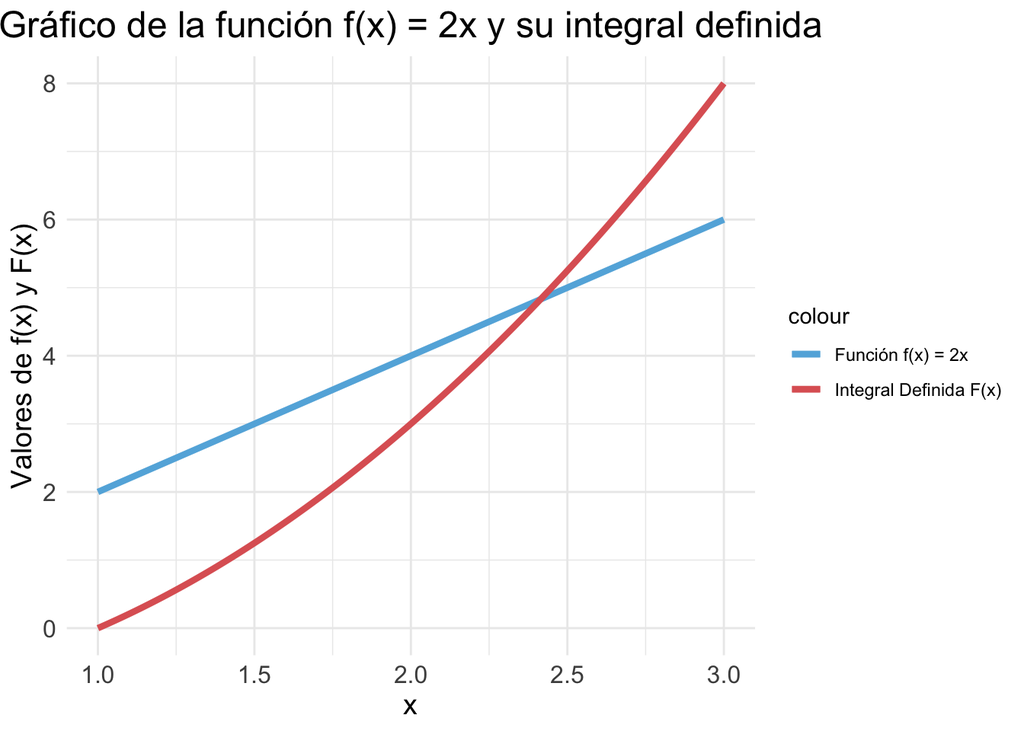

Gráfico de la función f(x) y su integral definida

```r
# Load required library
library(ggplot2)

# Create a vector of x values from 1 to 3
x_values <- seq(1, 3, 0.01)

# Calculate the corresponding y values for the function f(x) = 2x
y_values <- 2 * x_values

# Calculate the corresponding values for the integral of f(x) = 2x
F_x_values <- x_values^2 - 1

# Create a plot for the function f(x) = 2x and the area under the curve
grafico_teorema_fundamental <- ggplot(data.frame(x = x_values, y = y_values, F_x = F_x_values), aes(x)) +
  geom_line(aes(y = y_values, color = "Función f(x) = 2x"), size = 1.5) +
  geom_line(aes(y = F_x_values, color = "Integral Definida F(x)"), size = 1.5) +
  labs(title = "Gráfico de la función f(x) = 2x y su integral definida",
       x = "x",
       y = "Valores de f(x) y F(x)") +
  scale_color_manual(values = c("#63B2DE", "#DE6363")) +
  theme_minimal() +
  theme(plot.title = element_text(size = 18, hjust = 0.5),
        axis.title = element_text(size = 14),
        axis.text = element_text(size = 12))

print(grafico_teorema_fundamental)
```

### 6.5 Aplicación

Supongamos que una elección se lleva a cabo a lo largo de un día (de t = 0 a t = 24). La función $V(t) = 100t^2$ representa la cantidad de votos acumulados a la hora $t$. Para obtener una estimación del total de votos emitidos durante el día, podríamos calcular la integral de $V(t)$ de 0 a 24.

Primero, definimos la función $V(t)$ y luego calculamos la integral en el intervalo deseado:

```r
# Define the function V(t)
V <- function(t) {
  return(100 * t^2)
}

# Calculate the integral of V(t) from 0 to 24
delta_t <- 0.01
total_votos_estimado <- sum(V(seq(0, 24, delta_t))) * delta_t

total_votos_estimado
```

```
## [1] 461088
```

## 7. Teorema Fundamental del Cálculo

### 7.1 Enunciado

El Teorema Fundamental del Cálculo constituye un puente entre la diferenciación y la integración, dos conceptos centrales en el cálculo. Este teorema, en esencia, nos permite evaluar integrales definidas mediante la aplicación del concepto de diferenciación. Se compone de dos partes que juntas forman una explicación coherente de cómo estas dos operaciones fundamentales en cálculo se interrelacionan.

#### Teorema Fundamental del Cálculo (Primera Parte)

Dada una función $f(x)$ que es continua en un intervalo $[a, b]$, y otra función $F(x)$ que simboliza la integral definida de $f(x)$ sobre el intervalo $[a, x]$, es decir,

$$F(x) = \int_{a}^{x} f(t) \, dt$$

entonces, de acuerdo con la primera parte del Teorema Fundamental del

Cálculo, la derivada de $F(x)$ con respecto a $x$ es precisamente $f(x)$:

$$\frac{d}{dx} F(x) = f(x)$$

Esta parte del teorema afirma que si una función $F$ es una antiderivada de $f$ en el intervalo, entonces la derivada de la integral de $f$ de $a$ a $x$ es la función misma.

#### Teorema Fundamental del Cálculo (Segunda Parte)

Supongamos que $f(x)$ es una función continua en el intervalo $[a, b]$ y $F(x)$ es una función que representa la integral definida de $f(x)$ de $a$ a $x$, es decir,

$$F(x) = \int_{a}^{x} f(t) \, dt$$

Entonces, según la segunda parte del Teorema Fundamental del Cálculo, la integral definida de $f(x)$ en el intervalo $[a, b]$ puede calcularse de la siguiente manera:

$$\int_{a}^{b} f(x) \, dx = F(b) - F(a)$$

Esta parte del teorema simplifica el cálculo de las integrales definidas al evaluar la función antiderivada en los extremos del intervalo.

### 7.2 Ejemplo, Cómputo y Representación Gráfica

Consideremos la función $f(x) = 2x^2 + 3$ en el intervalo $[1, 3]$.

1. Calculemos la integral definida de $f(x)$ en el sub-intervalo $[1, 2]$ utilizando el Teorema Fundamental del Cálculo.

Primero necesitamos encontrar una antiderivada $F(x)$ de $f(x)$. En este caso, una antiderivada de $f(x) = 2x^2 + 3$ es $F(x) = \frac{2x^3}{3} + 3x$. La obtenemos integrando $f(x)$ desde 1 hasta $x$:

$$F(x) = \int_{1}^{x} (2t^2 + 3) \, dt$$

Que nos da:

$$F(x) = \left[ \frac{2t^3}{3} + 3t
\right]_{1}^{x} = \frac{2x^3}{3} + 3x - \frac{2}{3} - 3$$

2. Ahora, calculemos la integral definida de $f(x)$ en el sub-intervalo $[1, 2]$ utilizando la segunda parte del Teorema Fundamental del Cálculo:

$$\int_{1}^{2} (2x^2 + 3) \, dx = F(2) -
F(1) = \left(\frac{2*2^3}{3} + 3*2 - \frac{2}{3} - 3\right) -
\left(\frac{2*1^3}{3} + 3*1 - \frac{2}{3} - 3\right) = \frac{23}{3}$$

Por lo tanto, el área bajo la curva $f(x) = 2x^2 + 3$ desde $x = 1$ hasta $x = 2$ es de $\frac{23}{3}$ unidades.

Ahora, vamos a visualizar esto con un gráfico en R:

Primero, creamos un vector de valores $x$ en el rango de 1 a 3:

```r
# Create a sequence of x values from 1 to 3
x_values <- seq(1, 3, 0.01)
```

Luego, calculamos los correspondientes valores de $y$ para la función $f(x) = 2x^2 + 3$:

```r
# Calculate the corresponding y values for the function f(x) = 2x^2 + 3
y_values <- 2 * x_values^2 + 3
```

Y creamos un gráfico que muestre la función $f(x) = 2x^2 + 3$ y el área bajo la curva en el sub-intervalo $[1, 2]$:

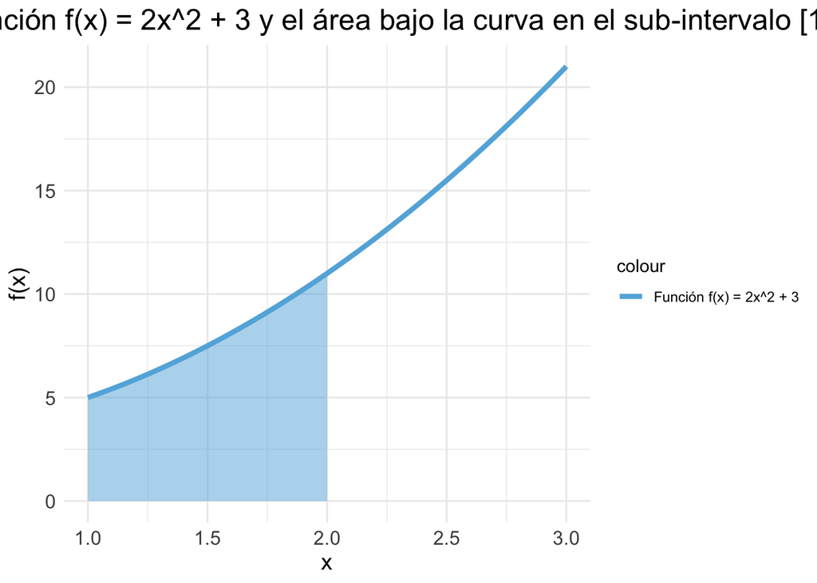

```r
# Create a plot for the function f(x) = 2x^2 + 3 and the area under the curve in the interval [1, 2]
grafico_integral <- ggplot(data.frame(x = x_values, y = y_values), aes(x, y)) +
  geom_line(aes(y = y, color = "Función f(x) = 2x^2 + 3"), size = 1.5) +
  geom_ribbon(data = data.frame(x = seq(1, 2, 0.01), y = 2 * seq(1, 2, 0.01)^2 + 3), aes(x, ymin = 0, ymax = y), fill = "#63B2DE", alpha = 0.5) +
  labs(title = "Gráfico de la función f(x) = 2x^2 + 3 y el área bajo la curva en el sub-intervalo [1, 2]",
       x = "x",
       y = "f(x)") +
  scale_color_manual(values = c("#63B2DE", "#DE6363")) +
  theme_minimal() +
  theme(plot.title = element_text(size = 18, hjust = 0.5),
        axis.title = element_text(size = 14),
        axis.text = element_text(size = 12))

print(grafico_integral)
```

Este gráfico muestra la función $f(x) = 2x^2 + 3$ y el área bajo la curva en el sub-intervalo $[1, 2]$, que corresponde a la integral definida que calculamos como $\frac{23}{3}$.

### 7.3 Aplicación

Supongamos que $p(t)$ es la tasa de cambio de población en una ciudad, en miles de personas por año, y está dada por la función $p(t) = 3t^2$, donde $t$ es el tiempo en años desde el inicio de 2020.

Para encontrar el cambio total en la población desde 2020 hasta 2023 (3 años), podríamos utilizar el Teorema Fundamental del Cálculo.

1. Primero, necesitamos encontrar una antiderivada $P(t)$ de $p(t)$. Esto se puede hacer integrando $p(t)$:

$$P(t) = \int_{0}^{t} 3t^2 \, dt$$

Resolviendo esto obtenemos:

$$P(t) = \left[ t^3 \right]_{0}^{t} = t^3$$

2. Ahora,

podemos calcular el cambio total en la población durante el intervalo $[0, 3]$ (desde 2020 hasta 2023) utilizando la segunda parte del Teorema Fundamental del Cálculo:

$$\int_{0}^{3} 3t^2 \, dt = P(3) - P(0) =
(3^3 - 0) = 27$$

Por lo tanto, la población de la ciudad aumentó en 27 mil personas durante estos 3 años.